# Part II - Communicate Data Findings: Prosper Loan Dataset

## by Hammed Jimoh

## Investigation Overview

> In this investigation, I want to check the relationship between Borrower's rate and other variables in the datasets. The main focus would be on but not limited to Loan original amount, borrower's monthly income, employment status and Loan term.

## Dataset Overview

> This data set contains 113,937 loans with 81 variables on each loan, including loan amount, borrower rate (or interest rate), current loan status, borrower income, and many others. After the necessary data wrangling processes, part of the dataset having 109,535 rows and 17 columns was explored.

## Distribution of key variables

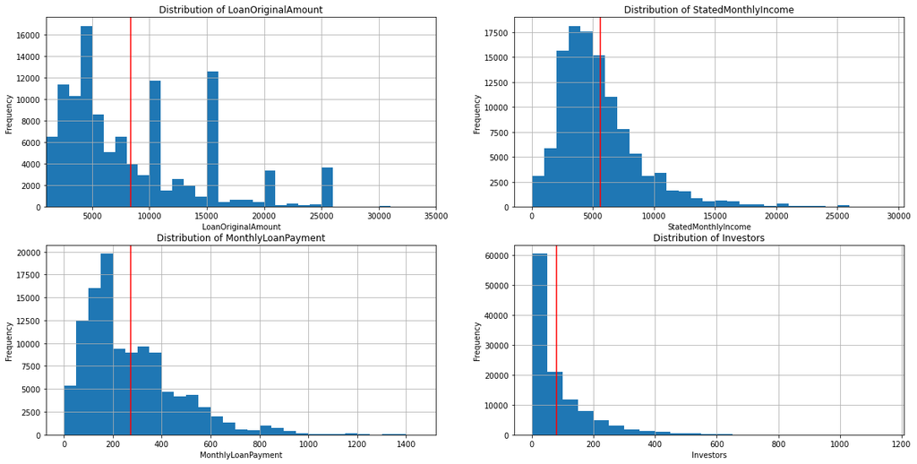

## What impact does loan original amount, stated monthly income, investors and year has on borrower's rate?

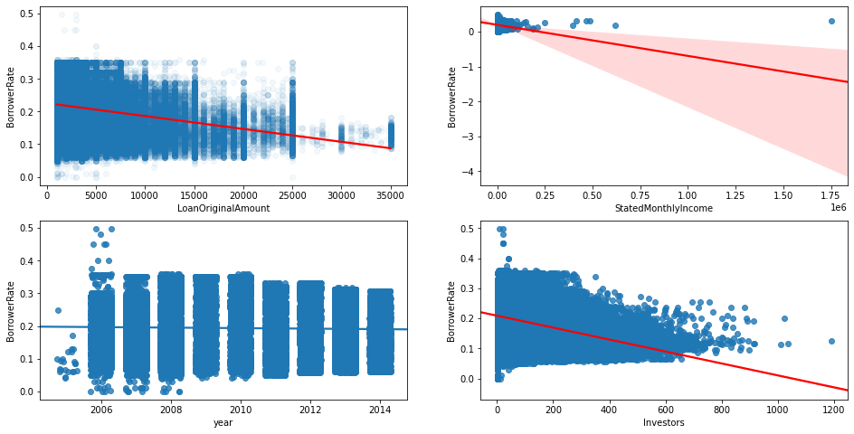

## Correlation between borrower's rate and other numerical variables

> It was actually surprising to see that BorrowerRate has a negative correlation with LoanOriginalAmount and weak correlation with Loan Term.

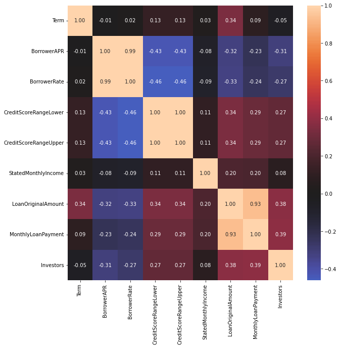